# EDA - bar plots

na

5/5/2022

Data Visualization: Categorical data / Bar-Plot

bar plot is a kind of graphs that we use to represent a categorical/discrete variable, by saying categorical, we mean a variable that can take a limited/specific elements on it. for example: today you have an exam, we can make some variable from today: 1) Binary variable: you will pass the exam, or not. 2) Categorical variable: the day(e.g. Sunday…), exam hour(e.g. 9:00, 13:30, 17:00…) And it’s also reasonable to add a third data type: Discrete data. 3) Discrete variables: the number of hours that you slept before the exam, the number of questions in the exam..

So, let’s start.

loading the libraries. I will try to use only ggplot2 functions, except if the alternative is much easier, and less code to write. plot_grid() function will be used a lot. I used it just to combine plots, as we shall see.

```r
library(ggplot2)
library(priceR)
library(dplyr)
library(forcats)
library(cowplot)
```

```r
## reading the data
###################
travel <- read.csv('TravelInsurancePrediction.csv')
## delete irrelevant variables
##############################
travel <- select(travel,-X)

## Change data type: Categorical variables
##########################################
travel$EmploymentType <- as.factor(travel$Employment.Type)
travel <- select(travel,-Employment.Type)
travel$GraduateOrNot <- as.factor(travel$GraduateOrNot)
travel$ChronicDiseases <- as.factor(travel$ChronicDiseases)
travel$FrequentFlyer <- as.factor(travel$FrequentFlyer)
travel$EverTravelledAbroad <- as.factor(travel$EverTravelledAbroad)
travel$TravelInsurance <- as.factor(travel$TravelInsurance)
usd_inr <- historical_exchange_rates("INR", to = "USD", start_date = "2019-01-01", end_date = "2019-12-31")[,2]
```

```
## For full currency exchange rate API documentation visit:
##  https://exchangerate.host/#/#docs
##  (this message will only appear once per session)
```

```r
travel$AnnualIncome <- travel$AnnualIncome*mean(usd_inr) #from INR currency to USD.
```

We will focus on plots, and will use just a couple of variable from travel dataset.

```r
str(travel)
```

```
## 'data.frame':    1987 obs. of  9 variables:
##  $ Age                : int  31 31 34 28 28 25 31 31 28 33 ...
##  $ GraduateOrNot      : Factor w/ 2 levels "No","Yes": 2 2 2 2 2 1 2 2 2 2 ...
##  $ AnnualIncome       : num  5690 17781 7112 9957 9957 ...
##  $ FamilyMembers      : int  6 7 4 3 8 4 4 3 6 3 ...
##  $ ChronicDiseases    : Factor w/ 2 levels "0","1": 2 1 2 2 2 1 1 1 2 1 ...
##  $ FrequentFlyer      : Factor w/ 2 levels "No","Yes": 1 1 1 1 2 1 1 2 2 2 ...
##  $ EverTravelledAbroad: Factor w/ 2 levels "No","Yes": 1 1 1 1 1 1 1 2 2 1 ...
##  $ TravelInsurance    : Factor w/ 2 levels "0","1": 1 1 2 1 1 1 1 2 2 1 ...
##  $ EmploymentType     : Factor w/ 2 levels "Government Sector",..: 1 2 2 2 2 2 1 2 2 1 ...
```

the variable that I used from the dataset: 1) TravelInsurance: a binary variable.

## a reminder.

If you forget one day how to make plot with ggplot2(Please don’t…), then you have to remember that you have to pass these three: 1) ggplot(and_here_the_dataset_name) 2) aes(x = the_variable_name_that_you_want_to_visualize, y = sec_col…) you can pass this aes thing(you should remember this) in ggplot() or geom_..() function. 3) geom_ the_plot_that_you_want: geom_bar(), geom_boxplot()….. so you should have: ggplot(travel,aes(TravelInsurance)) + geom_bar() |or| ggplot(travel) + geom_bar(aes(TravelInsurance))

## The basic bar-plot

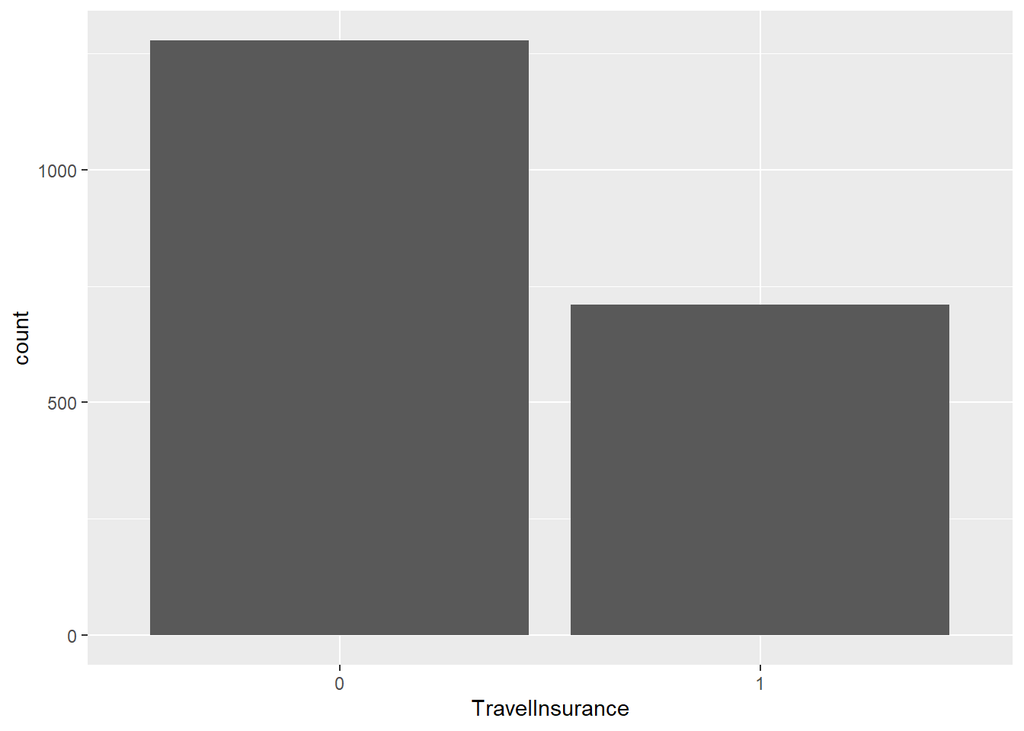

```r
ggplot(travel,aes(TravelInsurance)) + geom_bar()
```

we can also set the aesthetic in the geom function:

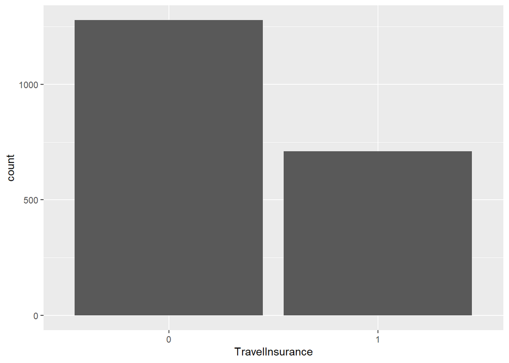

```r
ggplot(travel) + geom_bar(aes(TravelInsurance))
```

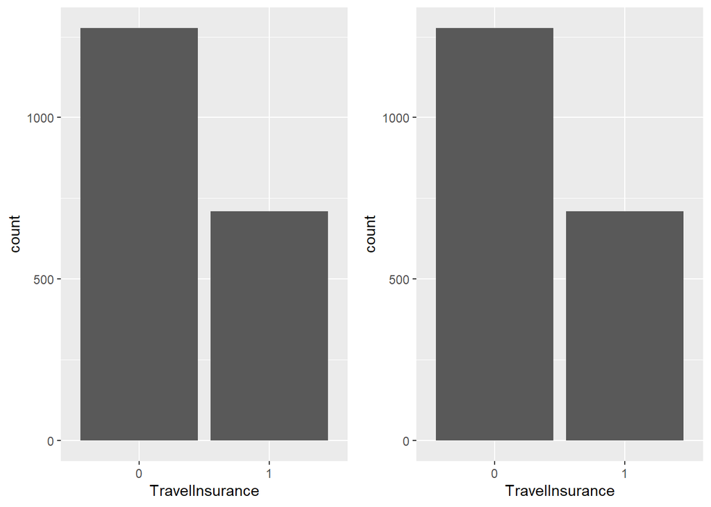

```r
plot_grid(ggplot(travel,aes(TravelInsurance)) + geom_bar(),
          ggplot(travel) + geom_bar(aes(TravelInsurance)))
```

as we can see: we have the same plot.

### add title, rename labs…

now we will gonna add a title, change x and y names. We have two options: 1)

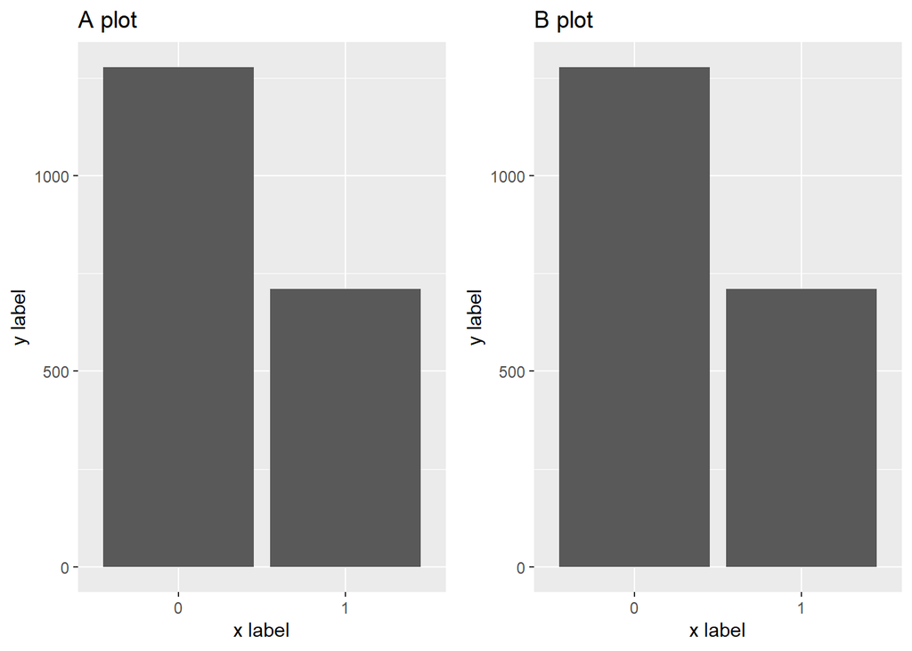

```r
p0 <- ggplot(travel,aes(TravelInsurance)) + geom_bar()
A <-  p0 + labs(x = 'x label', y = 'y label', title = 'A plot')
##
B <- p0 + xlab('x label') + ylab('y label') + ggtitle('B plot')
plot_grid(A,B)
```

other useful stuff with labs function:

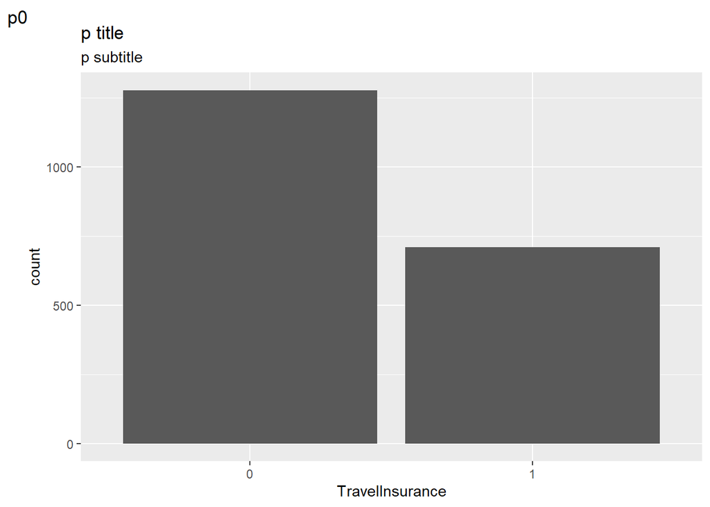

```r
p0 + labs(title = 'p title', subtitle = 'p subtitle', tag = 'p0')
```

### change axis limits.

change y axis limits:

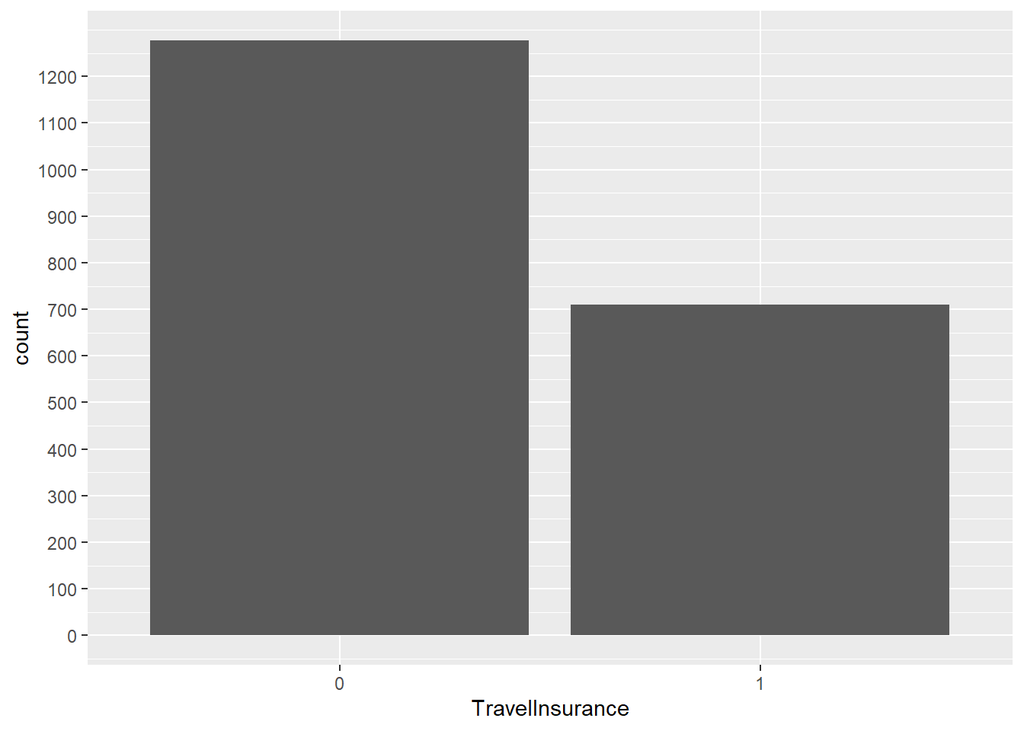

```r
p0 +  scale_y_continuous(limits=c(0,max(table(travel$TravelInsurance))), #future use: just change df$col
                         breaks=seq(0,max(table(travel$TravelInsurance)),100)) #you can change the by(100)
```

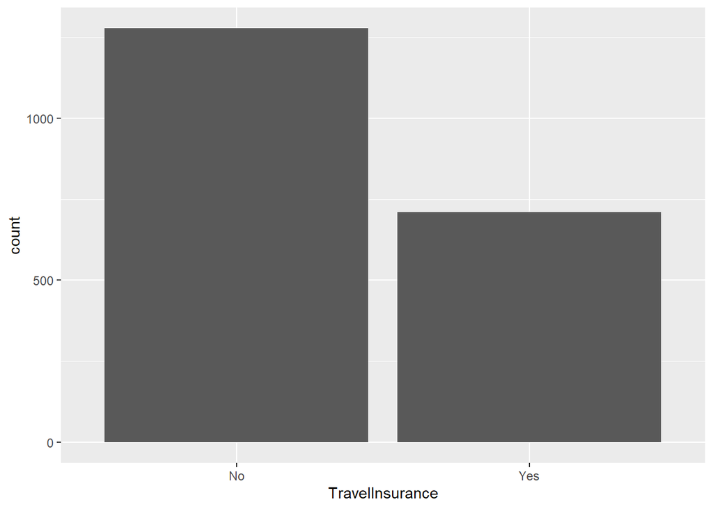

```r
p0 + scale_x_discrete(labels=c("No", "Yes"))
```

Note: since I don’t know which category ggplot package will put first, I have to see the plot before changing names. there is another way to do this, it’s require a little bit of work, but it worth it: create a new column, make the plot and then you can delete it after you got want you want. so:

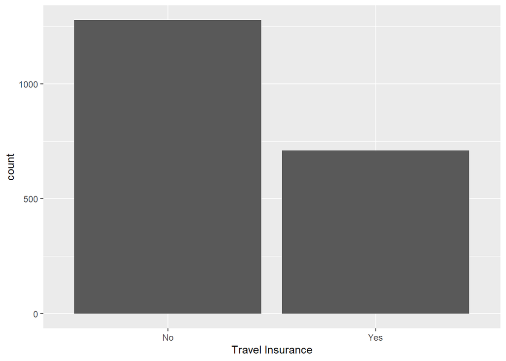

```r
#col <- rdunif(100,1,4)
#col_2 <- ifelse(col == 1,'one',ifelse(col==2,'two',ifelse(col == 3, 'three','four')))
#table(col)
#table(col_2)
n_col <- as.factor(ifelse(travel$TravelInsurance == 1,'Yes','No'))
ggplot(travel,aes(n_col)) + geom_bar() + xlab('Travel Insurance')
```

```r
remove(n_col)
```

### change font size, rotate…

change font size:

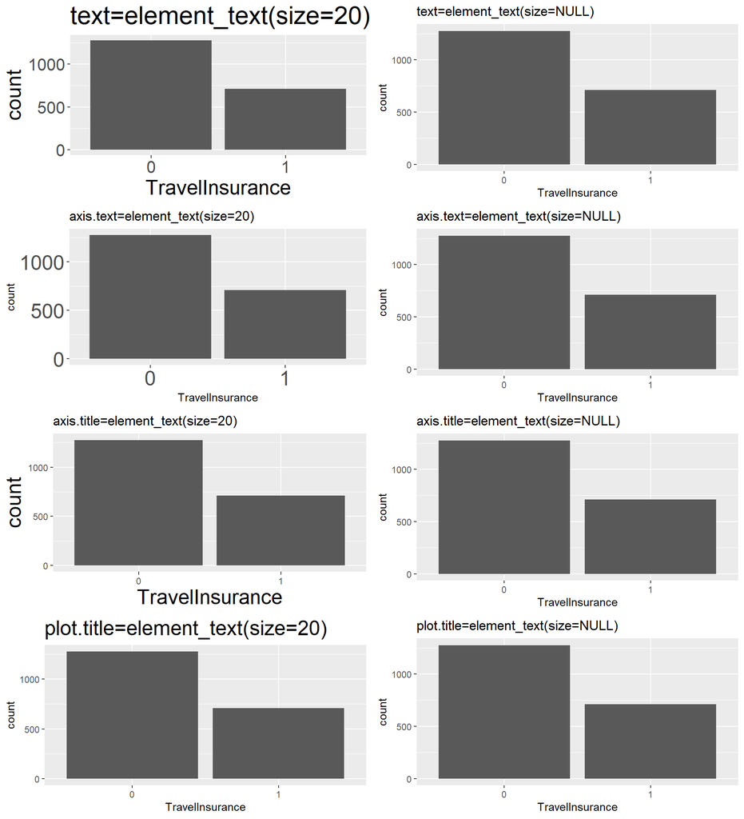

```r
plot_grid(p0 + theme(text=element_text(size=20)) + ggtitle('text=element_text(size=20)'),
          p0 + ggtitle('text=element_text(size=NULL)'),
          p0 + theme(axis.text=element_text(size=20)) + ggtitle('axis.text=element_text(size=20)'),
          p0 + ggtitle('axis.text=element_text(size=NULL)'),
          p0 + theme(axis.title=element_text(size=20)) + ggtitle('axis.title=element_text(size=20)'),
          p0 + ggtitle('axis.title=element_text(size=NULL)'),
          p0 + theme(plot.title=element_text(size=20)) + ggtitle('plot.title=element_text(size=20)'),
          p0 + ggtitle('plot.title=element_text(size=NULL)'),
          ncol = 2)
```

rotate, change text position:

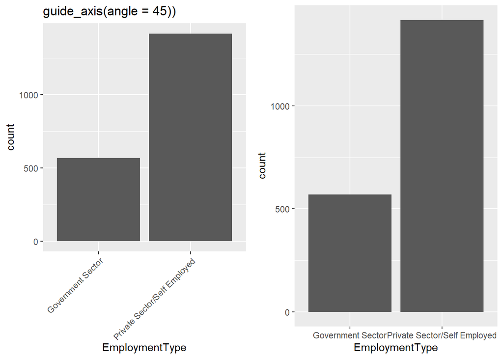

```r
r0 <- ggplot(travel, aes(EmploymentType)) + geom_bar()
plot_grid(r0 + scale_x_discrete(guide = guide_axis(angle = 45)) + ggtitle('guide_axis(angle = 45))'),
          r0)
```

another option:

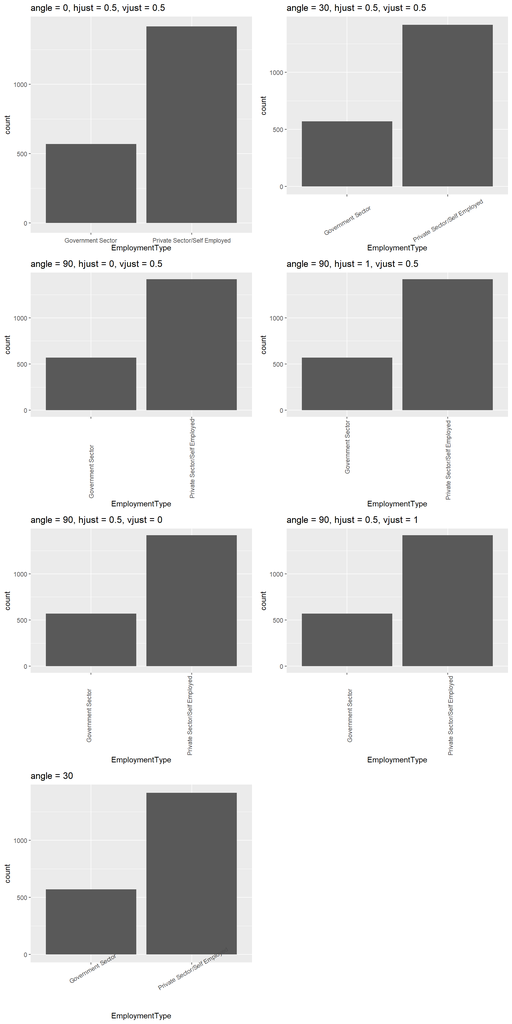

```r
plot_grid(r0 + theme(axis.text.x=element_text(angle = 0,    #rotate the text
                                    hjust = 0.5,   #text position from the center -left\right(horizontal)
                                    vjust = 0)) +  #text position -up\down(vertical)
                  ggtitle('angle = 0, hjust = 0.5, vjust = 0.5'),
          r0 + theme(axis.text.x=element_text(angle = 30, hjust = 0.5, vjust = 0.5)) + #plot[1,2]
                  ggtitle('angle = 30, hjust = 0.5, vjust = 0.5'),
          r0 + theme(axis.text.x=element_text(angle = 90, hjust = 0, vjust = 0.5)) + #plot[2,1]
                  ggtitle('angle = 90, hjust = 0, vjust = 0.5'),
          r0 + theme(axis.text.x=element_text(angle = 90, hjust = 1, vjust = 0.5)) + #plot[2,2]
                  ggtitle('angle = 90, hjust = 1, vjust = 0.5'),
          r0 + theme(axis.text.x=element_text(angle = 90, hjust = 0.5, vjust = 0)) + #plot[3,1]
                  ggtitle('angle = 90, hjust = 0.5, vjust = 0'),
          r0 + theme(axis.text.x=element_text(angle = 90, hjust = 0.5, vjust = 1)) + #plot[3,2]
                  ggtitle('angle = 90, hjust = 0.5, vjust = 1'),
          r0 + theme(axis.text.x=element_text(angle = 30)) + #plot[4,1]
                  ggtitle('angle = 30'),
          ncol = 2)
```

### Horizontal bars.

Horizontal bar plot:

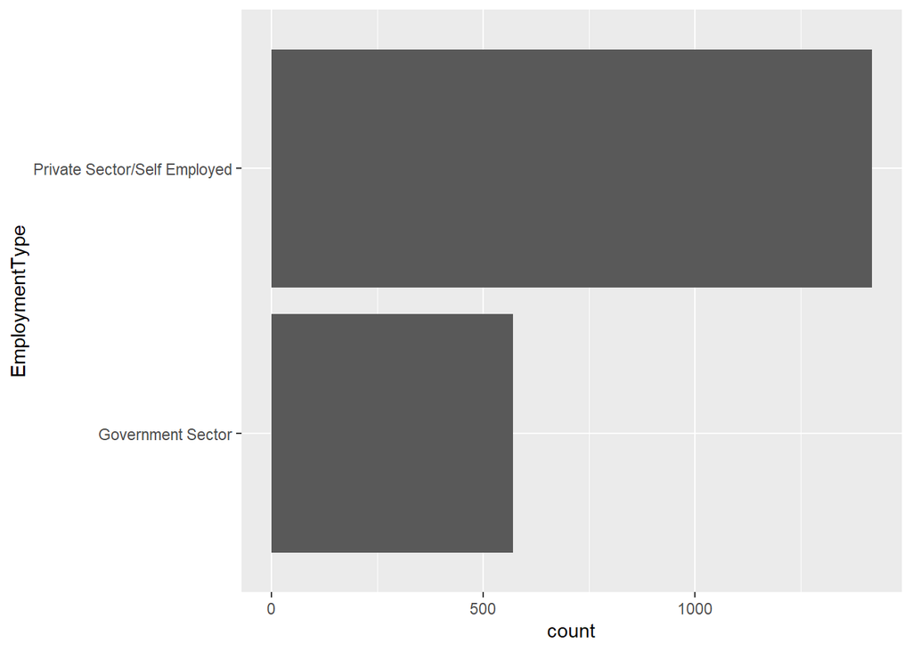

```r
r0 + coord_flip()
```

### other backgrounds.

change the background:

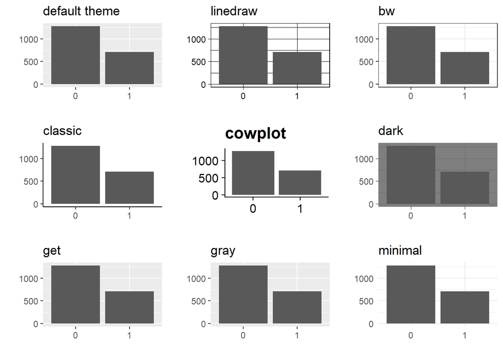

```r
p1 <- p0 + labs(x = '',y='')
plot_grid(p1 + ggtitle('default theme'),
          p1 + ggtitle('linedraw') + theme_linedraw(),
          p1 + ggtitle('bw') + theme_bw(),
          p1 + ggtitle('classic') + theme_classic(),
          p1 + ggtitle('cowplot') + theme_cowplot(),
          p1 + ggtitle('dark') + theme_dark(),
          p1 + ggtitle('get') + theme_get(),
          p1 + ggtitle('gray') + theme_gray(),
          p1 + ggtitle('minimal') + theme_minimal())
```

### color the bars. change colors:

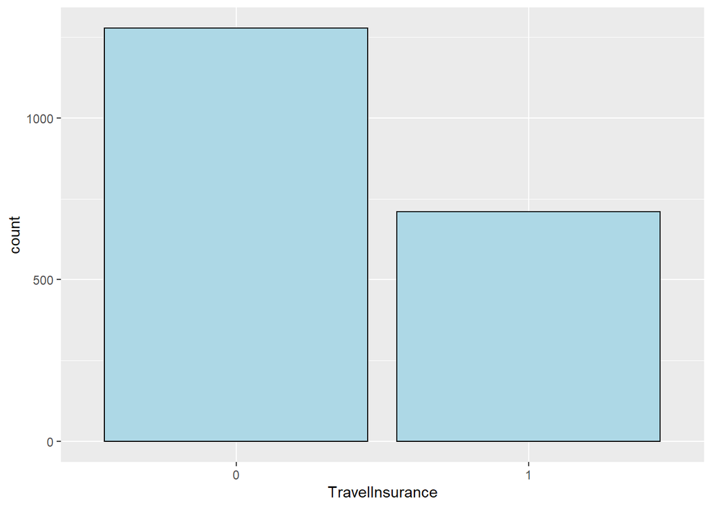

```r
ggplot(travel,aes(TravelInsurance)) + geom_bar(fill = 'lightblue',color = 'black')
```

### set the order.

reorder the bars by count: we can do this plot we less code with forcats library:

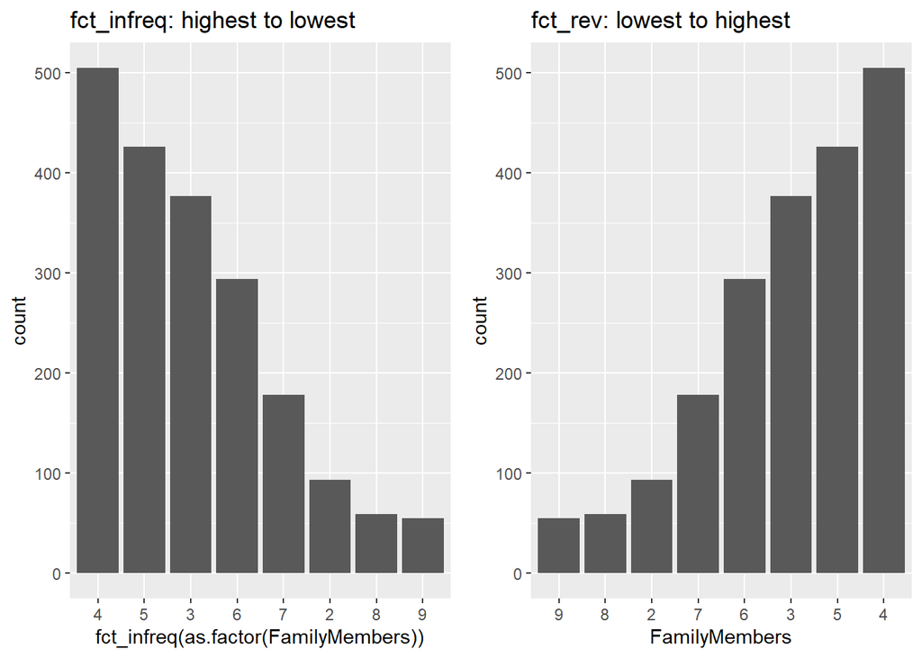

```r
#library(forcats)
plot_grid(ggplot(travel,aes(x = fct_infreq(as.factor(FamilyMembers)))) + geom_bar() +
            #labs(x = "FamilyMembers") +
                  ggtitle('fct_infreq: highest to lowest'),
          ggplot(travel,aes(x = fct_rev(fct_infreq(as.factor(FamilyMembers))))) + geom_bar() +
            labs(x = "FamilyMembers") +
                  ggtitle('fct_rev: lowest to highest'))
```

### add count, percentage…

add count:

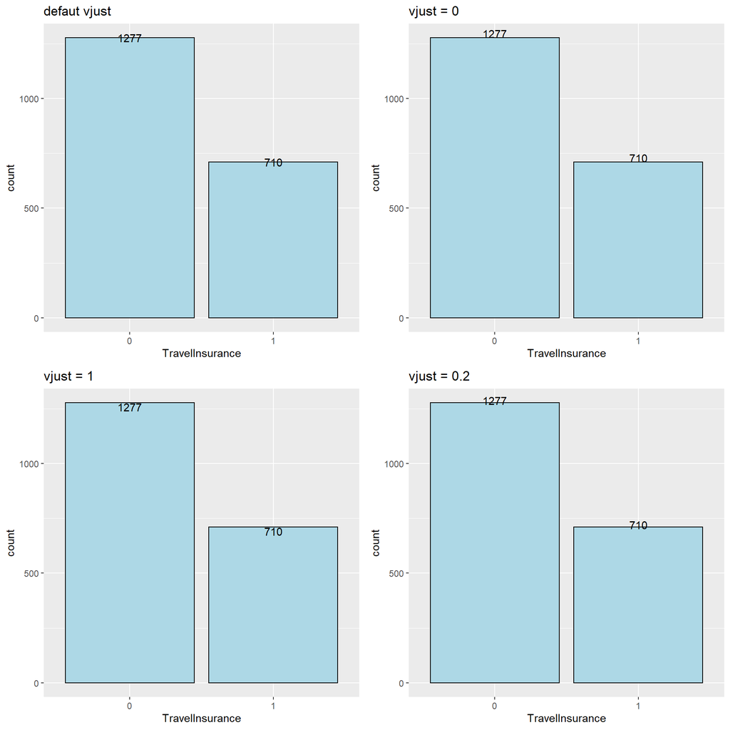

```r
c0 <-  ggplot(travel,aes(TravelInsurance)) + geom_bar(fill = 'lightblue',color = 'black')

plot_grid(c0 + geom_text(stat='count', aes(label=..count..)) + ggtitle('defaut vjust'),
          c0 + geom_text(stat='count', aes(label=..count..), vjust = 0) + ggtitle('vjust = 0'),
          c0 + geom_text(stat='count', aes(label=..count..), vjust = 1) + ggtitle('vjust = 1'),
          c0 + geom_text(stat='count', aes(label=..count..), vjust = 0.2) + ggtitle('vjust = 0.2'))
```

add percentage:

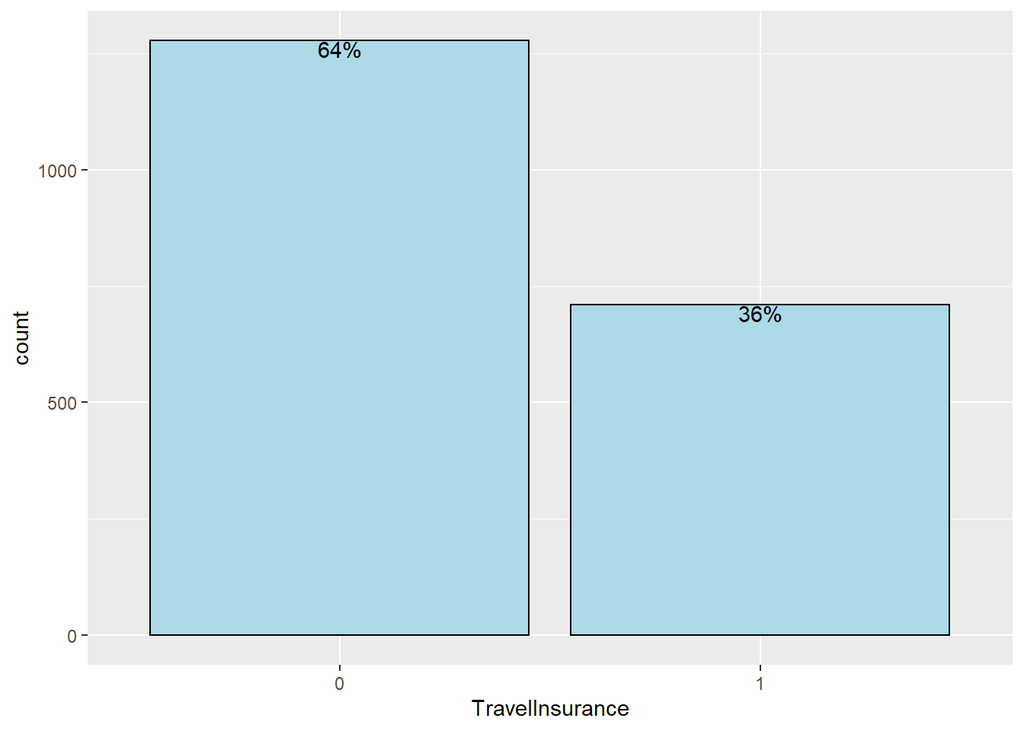

```r
c0 + geom_text(stat='count', aes(label = scales::percent(..count../sum(..count..))), vjust = 1)
```

count and proportion:

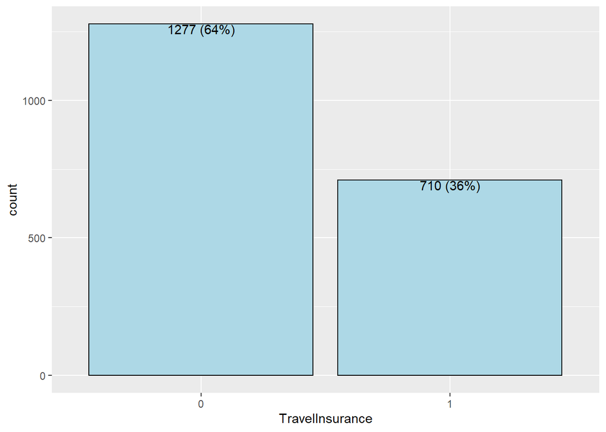

```r
c0 + geom_text(stat = "count",aes(label = paste(..count..," (",scales::percent(..count../sum(..count..)),")", sep = "")),
             vjust = 1)
```

that’s for bar plot with one variable, now we will see bar plots with more than one.

## a second categorical variable

second variable: categorical variable. color by another variable:

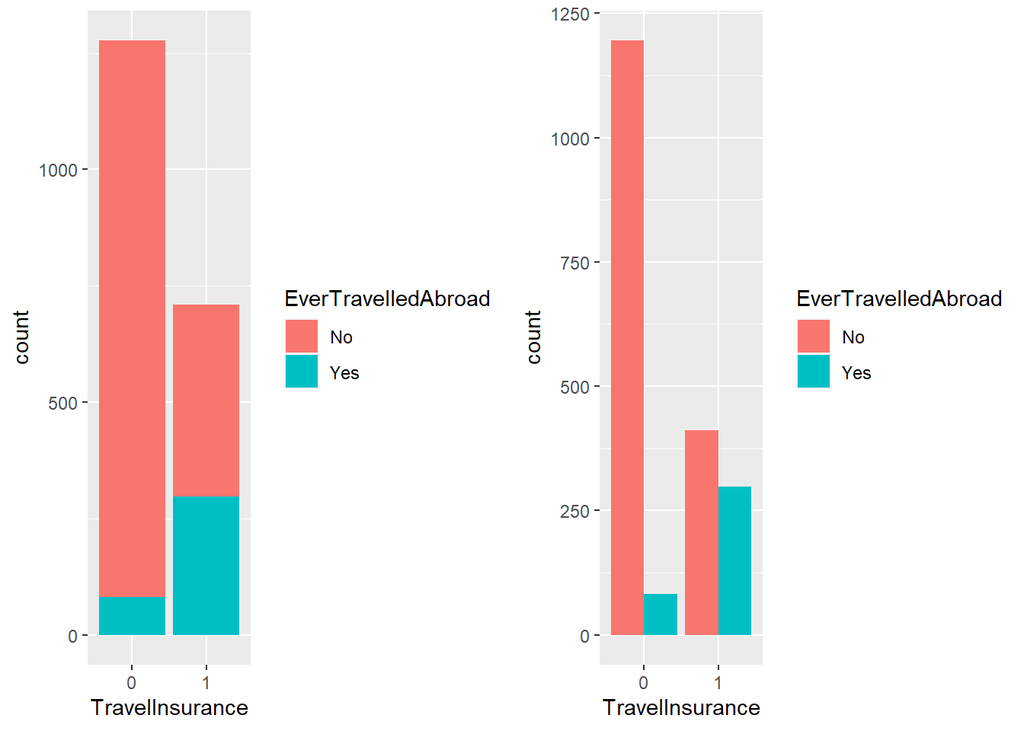

```r
plot_grid(ggplot(travel, aes(TravelInsurance)) + geom_bar(aes(fill = EverTravelledAbroad)),
          ggplot(travel, aes(TravelInsurance)) + geom_bar(aes(fill = EverTravelledAbroad), position="dodge"))
```

### change colors and legend positions

the colors changes by the second variable.

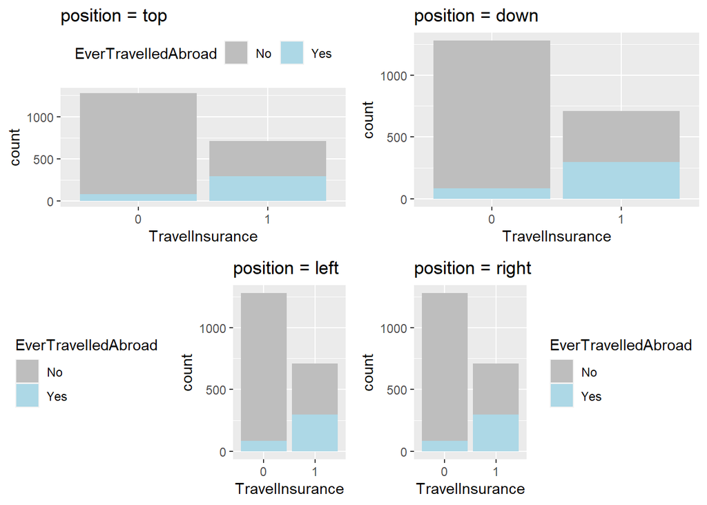

```r
plot_grid(ggplot(travel, aes(TravelInsurance)) + geom_bar(aes(fill = EverTravelledAbroad)) +
        theme(legend.position="top") + scale_fill_manual(values=c('grey','lightblue')) + ggtitle('position = top'),
        ggplot(travel, aes(TravelInsurance)) + geom_bar(aes(fill = EverTravelledAbroad)) +
        theme(legend.position="down") + scale_fill_manual(values=c('grey','lightblue')) + ggtitle('position = down'),
        ggplot(travel, aes(TravelInsurance)) + geom_bar(aes(fill = EverTravelledAbroad)) +
        theme(legend.position="left") + scale_fill_manual(values=c('grey','lightblue')) + ggtitle('position = left'),
        ggplot(travel, aes(TravelInsurance)) + geom_bar(aes(fill = EverTravelledAbroad)) +
        theme(legend.position="right") + scale_fill_manual(values=c('grey','lightblue')) + ggtitle('position = right'),
        ncol = 2)
```